# Capstone_project

JBlanco

2023-10-20

# Libraries

```r
rm(list = ls())

library(tidyverse)
library(lubridate)
library(scales)
library(sf)
library(viridis)
```

# Functions

### bound_coord

This function was created specifically to see which are the maximum or minimum values for the latitudes and longitudes of the data. This way one can see where the data is located

```r
bound_coord <- function(dataset, bound = max, coord = 'lat') {
  # The function prints the max and min values of the coordinates of the start and end positions.
  # bound is a function, can be max() or min(), coord can be the latitude (lat) or longitude (lon).

  if (coord == 'lat') {

    df <- select(dataset, start_lat, end_lat) %>%
      mutate(end_lat = na_if(end_lat, 0), start_lat = na_if(start_lat, 0))

    print(bound(df$start_lat, na.rm = TRUE))
    print(bound(df$end_lat, na.rm = TRUE))


  } else if (coord == 'long') {

    df <- select(dataset, start_lng, end_lng) %>%
      mutate(end_lng = na_if(end_lng, 0), start_lng = na_if(start_lng, 0)) %>%
      arrange(desc(start_lng), desc(end_lng))

    print(bound(df$start_lng, na.rm = TRUE))
    print(bound(df$end_lng, na.rm = TRUE))


  } else {

    stop('variable `coord` is not lat nor long')
  }}
```

### distance_lat_lon

```r
distance_lat_lon <- function(lat_1, lon_1, lat_2, lon_2) {

  rad_earth <-  6371 #km

  # Convert to radians

  theta_1 <- lat_1*pi/180
  theta_2 <- lat_2*pi/180
  phi_1 <- lon_2*pi/180
  phi_2 <- lon_2*pi/180

  # Use formula for displacement

  displacement <-  2*rad_earth*asin(sqrt(sin((theta_2-theta_1)/2)^2+cos(theta_2)*cos(theta_1)*sin((phi_2-phi_1)/2)^2))
}
```

# PREPARE

## Importing the data

All the .csv files were downloaded in the same directory. The following binds all the data from each month into a single dataframe.

```r
setwd('~/Desktop/DS/Case_study_1/Cyclist_trip_data/') #Go to the data directory

files <- list.files(getwd(), '*.csv') # Make a list of all .csv files

df_list <- lapply(files, read.csv) #Applies the function read.csv to all csv files

#So now we have a list of data frames for all the files
#The following joins all the data frames of the list in a single one

trip_data <- do.call(rbind, df_list) # The rbind binds multiple groups of rows while the do.call applies rbind using the parameters from the list. This way it isn't a list anymore
```

Just to check the dataframe has been loaded correctly

```r
glimpse(trip_data)
```

```
## Rows: 5,723,606
## Columns: 13
## $ ride_id            <chr> "550CF7EFEAE0C618", "DAD198F405F9C5F5", "E6F2BC47B6…
## $ rideable_type      <chr> "electric_bike", "electric_bike", "electric_bike", …
## $ started_at         <chr> "2022-08-07 21:34:15", "2022-08-08 14:39:21", "2022…
## $ ended_at           <chr> "2022-08-07 21:41:46", "2022-08-08 14:53:23", "2022…
## $ start_station_name <chr> "", "", "", "", "", "", "", "", "", "", "", "", "",…
## $ start_station_id   <chr> "", "", "", "", "", "", "", "", "", "", "", "", "",…
## $ end_station_name   <chr> "", "", "", "", "", "", "", "", "", "", "", "", "",…
## $ end_station_id     <chr> "", "", "", "", "", "", "", "", "", "", "", "", "",…
## $ start_lat          <dbl> 41.93, 41.89, 41.97, 41.94, 41.85, 41.79, 41.89, 41…
## $ start_lng          <dbl> -87.69, -87.64, -87.69, -87.65, -87.65, -87.72, -87…
## $ end_lat            <dbl> 41.94, 41.92, 41.97, 41.97, 41.84, 41.82, 41.89, 41…
## $ end_lng            <dbl> -87.72, -87.64, -87.66, -87.69, -87.66, -87.69, -87…
## $ member_casual      <chr> "casual", "casual", "casual", "casual", "casual", "…
```

```r
head(trip_data)
```

```
##            ride_id rideable_type          started_at            ended_at
## 1 550CF7EFEAE0C618 electric_bike 2022-08-07 21:34:15 2022-08-07 21:41:46
## 2 DAD198F405F9C5F5 electric_bike 2022-08-08 14:39:21 2022-08-08 14:53:23
## 3 E6F2BC47B65CB7FD electric_bike 2022-08-08 15:29:50 2022-08-08 15:40:34
## 4 F597830181C2E13C electric_bike 2022-08-08 02:43:50 2022-08-08 02:58:53
## 5 0CE689BB4E313E8D electric_bike 2022-08-07 20:24:06 2022-08-07 20:29:58
## 6 BFA7E7CC69860C20 electric_bike 2022-08-08 13:06:08 2022-08-08 13:19:09
##   start_station_name start_station_id end_station_name end_station_id start_lat
## 1                                                                         41.93
## 2                                                                         41.89
## 3                                                                         41.97
## 4                                                                         41.94
## 5                                                                         41.85
## 6                                                                         41.79
##   start_lng end_lat end_lng member_casual
## 1    -87.69   41.94  -87.72        casual
## 2    -87.64   41.92  -87.64        casual
## 3    -87.69   41.97  -87.66        casual
## 4    -87.65   41.97  -87.69        casual
## 5    -87.65   41.84  -87.66        casual
## 6    -87.72   41.82  -87.69        casual
```

Now we can liberate some space

```r
rm(df_list)
```

There are some issues with the data, there are missing values in the stations names and IDs. However I don’t think that these variables are necessary since the dataframe has the start and end coordinates of the trip, which is enough geographical data.

To see the boundaries of the location of the trips

```r
print(paste('max latitudes', max(trip_data$start_lat), max(trip_data$end_lat)))
```

```
## [1] "max latitudes 42.07 NA"
```

```r
print(paste('min latitudes', min(trip_data$start_lat), min(trip_data$end_lat)))
```

```
## [1] "min latitudes 41.64 NA"
```

```r
print(paste('max longitudes', max(trip_data$start_lng), max(trip_data$end_lng)))
```

```
## [1] "max longitudes -87.52 NA"
```

```r
print(paste('min longitudes', min(trip_data$start_lng), min(trip_data$end_lng)))
```

```
## [1] "min longitudes -87.92 NA"
```

Since some NA values appear in the end locations, we must check how many rows have this issue

```r
end_loc_no_NA <- trip_data %>%
  select(end_lat, end_lng) %>%
  filter(!is.na(end_lat)) %>%
  filter(!is.na(end_lng)) %>%  # This is a df of the final location without the NA values
  glimpse()
```

```
## Rows: 5,717,504
## Columns: 2
## $ end_lat <dbl> 41.94, 41.92, 41.97, 41.97, 41.84, 41.82, 41.89, 41.92, 41.93,…
## $ end_lng <dbl> -87.72, -87.64, -87.66, -87.69, -87.66, -87.69, -87.61, -87.68…
```

```r
print(paste('max latitudes', max(end_loc_no_NA$end_lat)))
```

```
## [1] "max latitudes 42.18"
```

```r
print(paste('min latitudes', min(end_loc_no_NA$end_lat)))
```

```
## [1] "min latitudes 0"
```

```r
print(paste('max longitudes', max(end_loc_no_NA$end_lng)))
```

```
## [1] "max longitudes 0"
```

```r
print(paste('min longitudes', min(end_loc_no_NA$end_lng)))
```

```
## [1] "min longitudes -88.16"
```

Now we are obtaining a nonsense value like 0… how many rows contain this value?

(0 is a nonsense value for US coordinates)

```r
end_loc_no_NA %>%
  filter(end_lat == 0) %>%
  filter(end_lng == 0) %>%  # This is a df of the final location without the NA values
  glimpse()
```

```
## Rows: 10
## Columns: 2
## $ end_lat <dbl> 0, 0, 0, 0, 0, 0, 0, 0, 0, 0
## $ end_lng <dbl> 0, 0, 0, 0, 0, 0, 0, 0, 0, 0
```

There are only 10 rows, so we may delete these rows as well, this shouldn’t affect the results. Since there are around 6112 rows with NA or 0 values. this is about 0.1 % of the data, which can be neglected without important implications…

We can remove the 0s and NAs and print the boundaries of the coordinates

```r
bound_coord(trip_data, coord = 'lat', bound = min) # min_lat
```

```
## [1] 41.64
## [1] 41.55
```

```r
bound_coord(trip_data, coord = 'lat', bound = max) # max_lat
```

```
## [1] 42.07
## [1] 42.18
```

```r
bound_coord(trip_data, coord = 'long', bound = min) # min_lng
```

```
## [1] -87.92
## [1] -88.16
```

```r
bound_coord(trip_data, coord = 'long', bound = max) # max_lng
```

```
## [1] -87.52
## [1] -87.3
```

Answers to the Guiding questions

- We can see that the majority of the data is located around Chicago, near the Michigan Lake. The range of latitudes is [ 41.55,42.18] The range of longitudes is [-88.16,-87.3]
- It is important to highlight that some rows don’t have the station names, however they still contain information about the location of the trip
- In this case the data can be biased depending on the season of the year it’s been analized, for example, people can ride bycicles more oftenly on summer than on winter. In this case, the data corresponds to the last year. Also, we can notice that the positions of the stations can differ significantly. This makes me think that the station’s position is a variable that needs to be carefully treated for analysis. Therefore we should consider rideable_type, times and dates of the rides, duration and position to distinguish the members, we will use the stations, but acknowledging that there’s an important amount of data missing.
- I believe there’s a limitation of the data because there’s not rider_id, so we don’t know if multiple rides were made by different people or the same person.
- It’s ok to simply analyze the data publicly since the dataset doesn’t contain any information about people or other sensible information. Furthermore, the data is public, so anyone should be able to access it
- The I don’t think there are any problems with the data, it is not clean, and there are a lot of empty spaces when it comes to the stations. I also need to check if the other columns are complete.

# CLEANING

Now, I’m going to check that other columns are complete. For this matter, I’m going to use a df that ignores the rows with missing locations

```r
df <- trip_data %>%
  mutate(end_lat = na_if(end_lat, 0), start_lat = na_if(start_lat, 0),
         end_lng = na_if(end_lng, 0), start_lng = na_if(start_lng, 0)) %>%
  filter(!is.na(end_lat), !is.na(end_lng), !is.na(start_lat), !is.na(start_lng))

df %>%
  filter_all(any_vars(is.na(.))) %>%
  head()
```

```
##  [1] ride_id            rideable_type      started_at         ended_at
##  [5] start_station_name start_station_id   end_station_name   end_station_id
##  [9] start_lat          start_lng          end_lat            end_lng
## [13] member_casual
## <0 rows> (or 0-length row.names)
```

The result shows 0 rows, therefore, there are not any NA values left to be checked

Now we have to continue with the data types, all columns are characters except for the latitudes and longitudes. As a result, started_at and ended_at are characters, but must be dates

```r
df$started_at <- as.POSIXct(df$started_at)

df$ended_at <- as.POSIXct(df$ended_at)

head(df)
```

```
##            ride_id rideable_type          started_at            ended_at
## 1 550CF7EFEAE0C618 electric_bike 2022-08-07 21:34:15 2022-08-07 21:41:46
## 2 DAD198F405F9C5F5 electric_bike 2022-08-08 14:39:21 2022-08-08 14:53:23
## 3 E6F2BC47B65CB7FD electric_bike 2022-08-08 15:29:50 2022-08-08 15:40:34
## 4 F597830181C2E13C electric_bike 2022-08-08 02:43:50 2022-08-08 02:58:53
## 5 0CE689BB4E313E8D electric_bike 2022-08-07 20:24:06 2022-08-07 20:29:58
## 6 BFA7E7CC69860C20 electric_bike 2022-08-08 13:06:08 2022-08-08 13:19:09
##   start_station_name start_station_id end_station_name end_station_id start_lat
## 1                                                                         41.93
## 2                                                                         41.89
## 3                                                                         41.97
## 4                                                                         41.94
## 5                                                                         41.85
## 6                                                                         41.79
##   start_lng end_lat end_lng member_casual
## 1    -87.69   41.94  -87.72        casual
## 2    -87.64   41.92  -87.64        casual
## 3    -87.69   41.97  -87.66        casual
## 4    -87.65   41.97  -87.69        casual
## 5    -87.65   41.84  -87.66        casual
## 6    -87.72   41.82  -87.69        casual
```

Also it is important to remember that there are empty strings in the station names, these values will be replaced by NAs to see how many rows contain NA values

```r
pre_cleaned_data <- df %>%
  mutate_all(~ifelse(. %in% c("", NA), NA, .))
```

Checking the rows with NA values

```r
incomplete_df <- filter_all(pre_cleaned_data, any_vars(is.na(.)))

glimpse(incomplete_df)
```

```
## Rows: 1,377,137
## Columns: 13
## $ ride_id            <chr> "550CF7EFEAE0C618", "DAD198F405F9C5F5", "E6F2BC47B6…
## $ rideable_type      <chr> "electric_bike", "electric_bike", "electric_bike", …
## $ started_at         <dbl> 1659929655, 1659991161, 1659994190, 1659948230, 165…
## $ ended_at           <dbl> 1659930106, 1659992003, 1659994834, 1659949133, 165…
## $ start_station_name <chr> NA, NA, NA, NA, NA, NA, NA, NA, NA, NA, NA, NA, NA,…
## $ start_station_id   <chr> NA, NA, NA, NA, NA, NA, NA, NA, NA, NA, NA, NA, NA,…
## $ end_station_name   <chr> NA, NA, NA, NA, NA, NA, NA, NA, NA, NA, NA, NA, NA,…
## $ end_station_id     <chr> NA, NA, NA, NA, NA, NA, NA, NA, NA, NA, NA, NA, NA,…
## $ start_lat          <dbl> 41.93, 41.89, 41.97, 41.94, 41.85, 41.79, 41.89, 41…
## $ start_lng          <dbl> -87.69, -87.64, -87.69, -87.65, -87.65, -87.72, -87…
## $ end_lat            <dbl> 41.94, 41.92, 41.97, 41.97, 41.84, 41.82, 41.89, 41…
## $ end_lng            <dbl> -87.72, -87.64, -87.66, -87.69, -87.66, -87.69, -87…
## $ member_casual      <chr> "casual", "casual", "casual", "casual", "casual", "…
```

There are 1377137 rows with empty strings, this represents around 25% of the data, thus, maybe is unnecessary to discard all of them, for example, those which have empty station names still contain important information.

The final revision will be for the member_casual column, since this is the most important column for distinguishing from both populations

```r
useless <- df %>%
  select(member_casual) %>%
  filter(. %in% c("member", "casual"))

glimpse(useless)
```

```
## Rows: 0
## Columns: 1
## $ member_casual <chr>
```

Since the useless df has 0 rows, there are not other values than member and casual.

I would also like to know if I can map the stations given the latitudes and longitudes, I’m going to make a list of all distinct stations and their locations

```r
start_stations_df <- df %>%
  select(start_station_name, start_lat, start_lng, start_station_id) %>%
  group_by(start_station_id) %>%
  summarise(av_lat = mean(start_lat), dev_lat = sd(start_lat),
            av_long = mean(start_lng), dev_lng = sd(start_lng)) %>%
  arrange(desc(dev_lat))

head(start_stations_df)
```

```
## # A tibble: 6 × 5
##   start_station_id                     av_lat dev_lat av_long dev_lng
##   <chr>                                 <dbl>   <dbl>   <dbl>   <dbl>
## 1 DIVVY CASSETTE REPAIR MOBILE STATION   41.9  0.101    -87.7  0.0371
## 2 560                                    41.9  0.0766   -87.7  0.0564
## 3 579                                    41.8  0.0748   -87.6  0.0978
## 4 569                                    41.8  0.0706   -87.6  0.0766
## 5 564                                    41.8  0.0701   -87.7  0.0533
## 6 559                                    41.8  0.0670   -87.7  0.0493
```

```r
view(start_stations_df)
```

```r
glimpse(start_stations_df)
```

```
## Rows: 1,503
## Columns: 5
## $ start_station_id <chr> "DIVVY CASSETTE REPAIR MOBILE STATION", "560", "579",…
## $ av_lat           <dbl> 41.85100, 41.87348, 41.78882, 41.80066, 41.81512, 41.…
## $ dev_lat          <dbl> 0.10136588, 0.07656689, 0.07478139, 0.07064698, 0.070…
## $ av_long          <dbl> -87.67101, -87.72967, -87.61360, -87.64075, -87.68352…
## $ dev_lng          <dbl> 0.037074316, 0.056441825, 0.097785879, 0.076609620, 0…
```

As we can see from this part, the locations of the stations repeat showing different coordinates and the uncertainties can be as high as around 0.1, therefore it wouldn’t be a good idea to fill the names of the stations using the coordinates of the ride as the ID. Also, there are over 1500 stations, so I believe it’s better to later make a list of the top 3-10 stations with a higher casual/member ratio, which are the stations of interest in order to target casual users.

### Displacement

In order to differentiate the member and casual populations I would like to compare the displacements, locations, dates and time of use to see if there are any differences

I found a formula that gives the displacements as a function of the initial and final angles, so I’ll add a column with the displacement

```r
#Add a column with the displacement in km (see function distance_lat_lon)
df <- mutate(df, displacement_km = distance_lat_lon(start_lat, start_lng, end_lat, end_lng))
```

### Duration

The duration of the ride can be a criteria to discard some data since rides shorter than a minute may not be valid for consideration.

```r
df <- df %>%
  mutate(duration_min = as.numeric(difftime(ended_at, started_at, units = 'mins')))

head(df)
```

```
##            ride_id rideable_type          started_at            ended_at
## 1 550CF7EFEAE0C618 electric_bike 2022-08-07 21:34:15 2022-08-07 21:41:46
## 2 DAD198F405F9C5F5 electric_bike 2022-08-08 14:39:21 2022-08-08 14:53:23
## 3 E6F2BC47B65CB7FD electric_bike 2022-08-08 15:29:50 2022-08-08 15:40:34
## 4 F597830181C2E13C electric_bike 2022-08-08 02:43:50 2022-08-08 02:58:53
## 5 0CE689BB4E313E8D electric_bike 2022-08-07 20:24:06 2022-08-07 20:29:58
## 6 BFA7E7CC69860C20 electric_bike 2022-08-08 13:06:08 2022-08-08 13:19:09
##   start_station_name start_station_id end_station_name end_station_id start_lat
## 1                                                                         41.93
## 2                                                                         41.89
## 3                                                                         41.97
## 4                                                                         41.94
## 5                                                                         41.85
## 6                                                                         41.79
##   start_lng end_lat end_lng member_casual displacement_km duration_min
## 1    -87.69   41.94  -87.72        casual        1.111949     7.516667
## 2    -87.64   41.92  -87.64        casual        3.335848    14.033333
## 3    -87.69   41.97  -87.66        casual        0.000000    10.733333
## 4    -87.65   41.97  -87.69        casual        3.335848    15.050000
## 5    -87.65   41.84  -87.66        casual        1.111949     5.866667
## 6    -87.72   41.82  -87.69        casual        3.335848    13.016667
```

It is important to check that the displacements and duration are reasonable

```r
df %>%
  select(displacement_km, duration_min) %>%
  mutate(avg_speed = displacement_km/duration_min) %>%
  arrange(desc(avg_speed)) %>%
  head()
```

```
##   displacement_km duration_min avg_speed
## 1    0.0005036018            0       Inf
## 2    0.0114530774            0       Inf
## 3    0.0959612217            0       Inf
## 4    0.2119745952            0       Inf
## 5    0.2146432734            0       Inf
## 6    0.1667553250            0       Inf
```

```r
df %>%
  filter(duration_min < 1) %>%
  glimpse()
```

```
## Rows: 151,717
## Columns: 15
## $ ride_id            <chr> "A27B8C1793E7D9BB", "0AFF818A103A86D4", "58D98EEFDD…
## $ rideable_type      <chr> "electric_bike", "electric_bike", "electric_bike", …
## $ started_at         <dttm> 2022-08-08 14:42:12, 2022-08-27 13:56:03, 2022-08-…
## $ ended_at           <dttm> 2022-08-08 14:42:19, 2022-08-27 13:56:28, 2022-08-…
## $ start_station_name <chr> "", "", "", "", "", "", "", "", "", "", "", "", "",…
## $ start_station_id   <chr> "", "", "", "", "", "", "", "", "", "", "", "", "",…
## $ end_station_name   <chr> "", "", "", "", "", "", "", "", "", "", "", "", "",…
## $ end_station_id     <chr> "", "", "", "", "", "", "", "", "", "", "", "", "",…
## $ start_lat          <dbl> 41.93000, 42.00000, 41.87000, 41.92000, 41.90000, 4…
## $ start_lng          <dbl> -87.76000, -87.69000, -87.63000, -87.67000, -87.690…
## $ end_lat            <dbl> 41.93000, 42.00000, 41.87000, 41.92000, 41.90000, 4…
## $ end_lng            <dbl> -87.76000, -87.69000, -87.63000, -87.67000, -87.690…
## $ member_casual      <chr> "casual", "member", "casual", "casual", "casual", "…
## $ displacement_km    <dbl> 0, 0, 0, 0, 0, 0, 0, 0, 0, 0, 0, 0, 0, 0, 0, 0, 0, …
## $ duration_min       <dbl> 0.11666667, 0.41666667, 0.48333333, 0.30000000, 0.8…
```

This trips need to be eliminated since represent mostly errors made by the users

```r
df <- df %>%
  filter(duration_min > 1)
```

Finally I’ll make a backup for the clean data

```r
write_csv(df, "cleaned_data.csv")
```

# ANALIZE

```r
# df <- read.csv("cleaned_data.csv")

#df$started_at <- as.POSIXct(df$started_at)

#df$ended_at <- as.POSIXct(df$ended_at)
```

### Displacement

In this part, I’m going to compare the displacements of members and casuals to see if there’s any difference.

```r
df %>%
  select(displacement_km, member_casual) %>%
  group_by(member_casual) %>%
  summarise(avg_displacement_km = mean(displacement_km))
```

[output not shown]

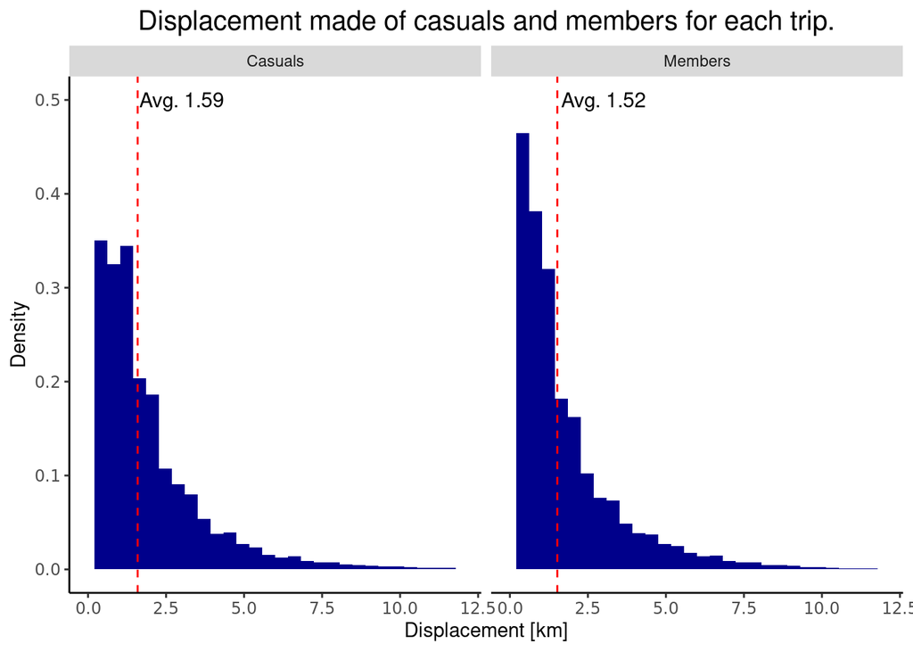

```r
dat_text <- data.frame(
  label = c('Avg. 1.59', "Avg. 1.52"),
  member_casual   = c('casual', 'member'),
  x = c(1.59, 1.52)
)


#Histograms of displacement for casuals and members:
ggplot(data = df, mapping = aes(x = displacement_km, y = ..density..)) +
  geom_histogram(bins = 30, fill = 'darkblue') +
  xlim(0,12) +
  facet_wrap(~member_casual, labeller = as_labeller(c('casual' = 'Casuals', 'member' = 'Members'))) + #Labels of facets
  geom_text(data = dat_text, mapping = aes(x = 1.65, y = 0.5, label = label), hjust = 'left', size = 4) +
  geom_vline(data = dat_text, aes(xintercept = dat_text$x), color = "red", linetype = "dashed") +
  labs(x = 'Displacement [km]',
       y = 'Density',
       title = 'Displacement made of casuals and members for each trip.') +
  theme(panel.grid.major = element_blank(),
        panel.grid.minor = element_blank(),
        panel.background = element_rect(fill = "white"),
        axis.line = element_line(color = 'black'),
        axis.text = element_text("black", size = 9),
        plot.title = element_text(hjust = 0.5, size = 15))
```

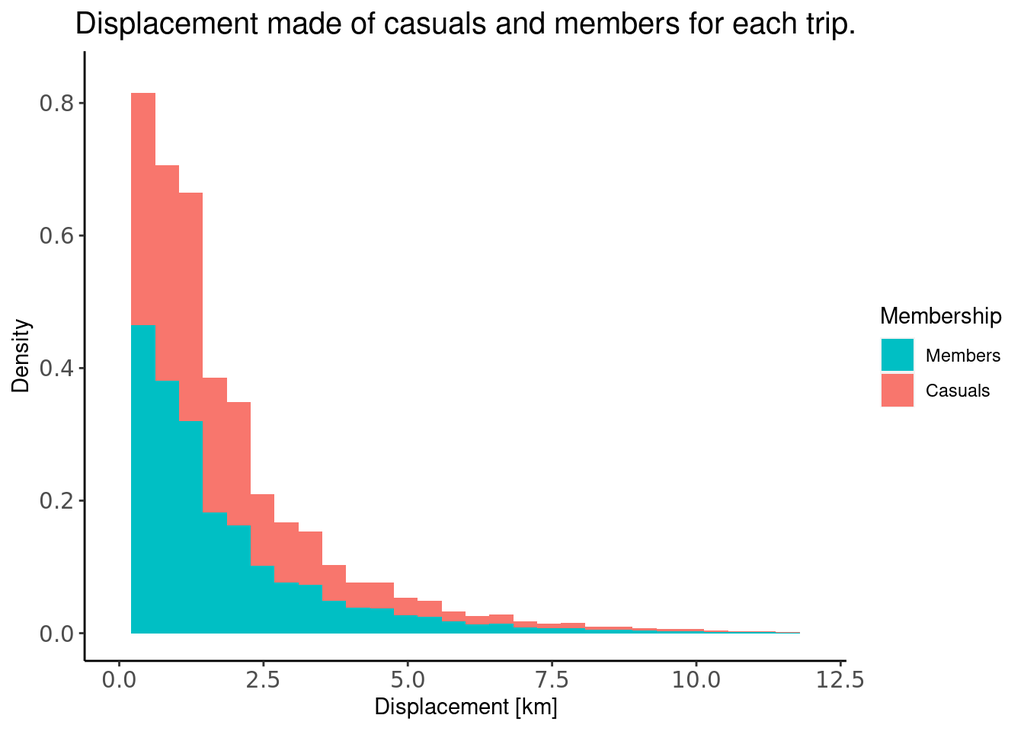

```r
ggplot(data = df, mapping = aes(x = displacement_km, y = ..density.., fill = member_casual)) +
  geom_histogram(bins = 30) +
  xlim(0,12) +
  labs(x = 'Displacement [km]',
       y = 'Density',
       title =  'Displacement made of casuals and members for each trip.', hjust = 'center') +
  scale_fill_discrete("Membership",
                      breaks=c("member","casual"),
                      labels=c("Members", "Casuals")) +
  theme(panel.grid.major = element_blank(),
        panel.grid.minor = element_blank(),
        panel.background = element_rect(fill = "white"),
        axis.line = element_line(color = 'black'),
        axis.text = element_text("black", size = 11),
        plot.title = element_text(hjust = 0.5, size = 15))
```

It can be seen qualitatively that the distributions are almost the same, so there’s no reason to believe that members or casuals make longer (in distance) rides. The first histogram shows a similar distribution and the second one can be useful to compare the heights of each bin, they have a similar height.

### Duration

```r
df %>%
  select(duration_min, member_casual) %>%
  group_by(member_casual) %>%
  summarise(avg_duration_min = mean(duration_min))
```

```
## # A tibble: 2 × 2
##   member_casual avg_duration_min
##   <chr>                    <dbl>
## 1 casual                    20.8
## 2 member                    12.4
```

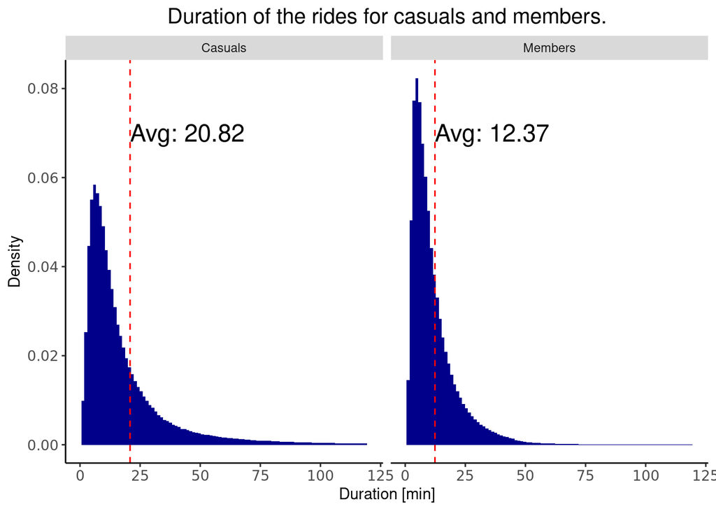

```r
dat_text <- data.frame(
  label = c("Avg: 20.82", "Avg: 12.37"),
  member_casual   = c('casual', 'member'),
  x = c(20.82, 12.37)
)


ggplot(data = df, mapping = aes(x = duration_min, y = ..density..)) +
  geom_histogram(bins = 100, fill = 'darkblue') +
  xlim(0, 120) +
  facet_wrap(~member_casual, labeller = as_labeller(c('casual' = 'Casuals', 'member' = 'Members'))) + #Labels of facets
  geom_text(data = dat_text, mapping = aes(x = dat_text$x, y = 0.07, label = label), hjust = 'left', size = 6) +
  geom_vline(data = dat_text, aes(xintercept = dat_text$x), color = "red", linetype = "dashed") +
  labs(x = 'Duration [min]',
       y = 'Density',
       title = 'Duration of the rides for casuals and members.') +
  theme(panel.grid.major = element_blank(),
        panel.grid.minor = element_blank(),
        panel.background = element_rect(fill = "white"),
        axis.line = element_line(color = 'black'),
        axis.text = element_text("black", size = 10),
        plot.title = element_text(hjust = 0.5, size = 15))
```

It looks like casual users use the bicycles for a longer period of time. This makes sense since one would expect that members use their bicycles for daily activities, like commuting to work.

### Days of the week

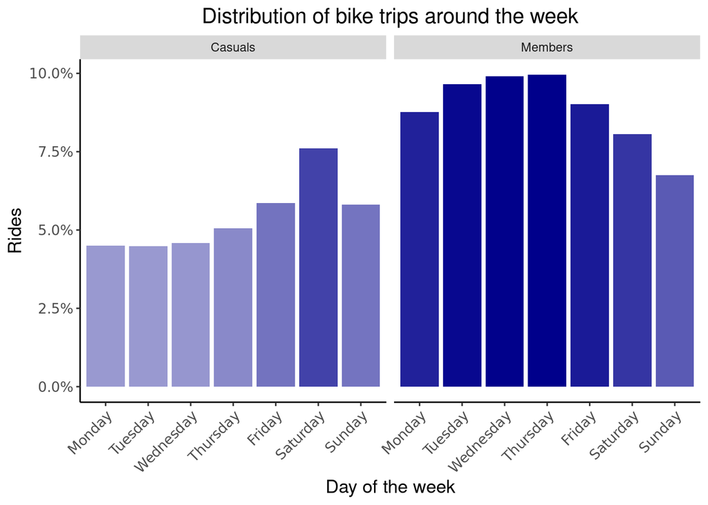

```r
color_df <- data.frame(
  color = c('darkred', 'darkblue'),
  member_casual   = c('member', 'casual')
)

ggplot(data = df, mapping = aes(x = factor(weekdays(started_at), levels = c("Monday", "Tuesday", "Wednesday", "Thursday", "Friday", "Saturday", "Sunday")), y = ..count../sum(..count..), alpha = (..count../sum(..count..)))) +
  geom_bar(fill = 'darkblue', show.legend = FALSE) +
  scale_y_continuous(labels = scales::percent) +
  labs(x = 'Day of the week',
       y = 'Rides',
       title = 'Distribution of bike trips around the week') +
  facet_wrap(~member_casual, labeller = as_labeller(c('casual' = 'Casuals', 'member' = 'Members'))) + #Labels of facets
  theme(panel.grid.major = element_blank(),
        panel.grid.minor = element_blank(),
        panel.background = element_rect(fill = "white"),
        axis.line = element_line(color = 'black'),
        axis.text = element_text("black", size = 10),
        axis.text.x = element_text(angle = 45, hjust = 1),
        axis.title = element_text(size = 13),
        plot.title = element_text(hjust = 0.5, size = 15)) +
  scale_alpha(range = c(0.4, 1))
```

There you can see that casuals ride more on weekends, specially on Saturdays whereas members do it preferably from Monday to Friday.

#### Time of the day

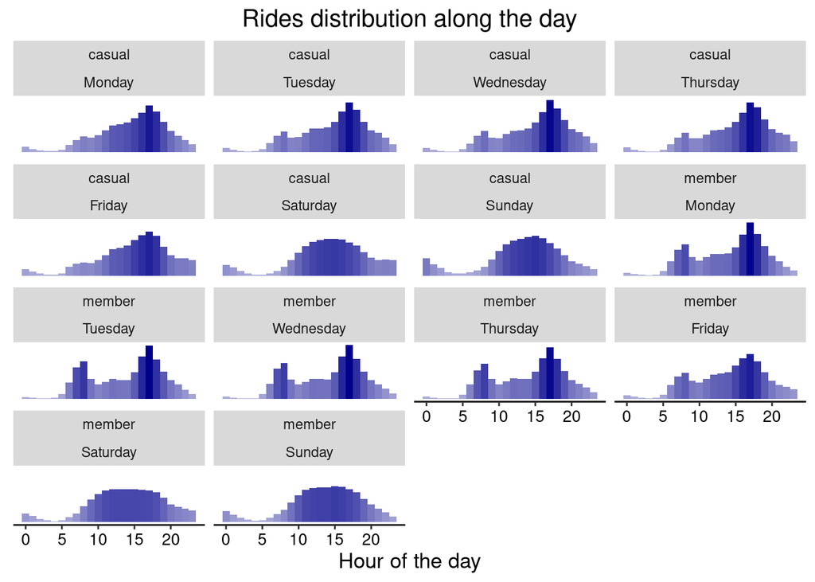

```r
# Convert weekdays to an ordered factor
df$weekday <- factor(weekdays(df$started_at), levels = c("Monday", "Tuesday", "Wednesday", "Thursday", "Friday", "Saturday", "Sunday"), ordered = TRUE)

# Plot the distribution of trips
ggplot(data = df, mapping = aes(x = hour(started_at), y = ..density.., alpha = ..density..)) +
 geom_histogram(bins = 24, fill = 'darkblue', show.legend = FALSE) +
 facet_wrap(~member_casual + weekday) +
 labs(x = 'Hour of the day',
    title = 'Rides distribution along the day') +
 theme(panel.grid.major = element_blank(),
    panel.grid.minor = element_blank(),
    panel.background = element_rect(fill = "white"),
    axis.line.x = element_line(color = 'black'),
    axis.text.x = element_text(color = "black", size = 10),
    axis.text.y = element_blank(),
    axis.title.y = element_blank(),
    axis.line.y = element_blank(),
    axis.ticks.y = element_blank(),
    axis.title = element_text(size = 13),
    plot.title = element_text(hjust = 0.5, size = 15)) +
 scale_alpha(range = c(0.3, 1))
```

There one can notice that the distributions are different from monday to friday from weekends, this effect is enhanced in members. From that we can see the distribution of trips by members and from monday to friday and weekends.

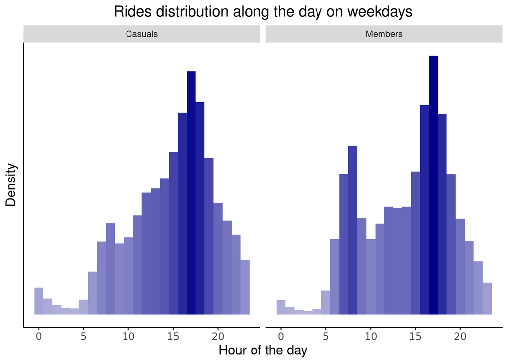

```r
df_mtf <- df %>%
  select(member_casual, started_at) %>%
  filter(!(weekdays(started_at) == 'Saturday' | weekdays(started_at) == 'Sunday'))

df_wke <- df %>%
  select(member_casual, started_at) %>%
  filter((weekdays(started_at) == 'Saturday' | weekdays(started_at) == 'Sunday'))

ggplot(data = df_mtf, mapping = aes(x = lubridate::hour(started_at), y = ..density.., alpha = ..density..)) +
  geom_histogram(bins = 24, fill = 'darkblue', show.legend = FALSE) +
  facet_wrap(~member_casual, labeller = as_labeller(c('casual' = 'Casuals', 'member' = 'Members'))) + #Labels of facets
  labs(x = 'Hour of the day',
       y = 'Density',
       title = 'Rides distribution along the day on weekdays') +
  theme(panel.grid.major = element_blank(),
        panel.grid.minor = element_blank(),
        panel.background = element_rect(fill = "white"),
        axis.line = element_line(color = 'black'),
        axis.text = element_text("black", size = 10),
        axis.text.y = element_blank(),
        axis.ticks.y = element_blank(),
        axis.title = element_text(size = 13),
        plot.title = element_text(hjust = 0.5, size = 15)) +
  scale_alpha(range = c(0.3, 1))
```

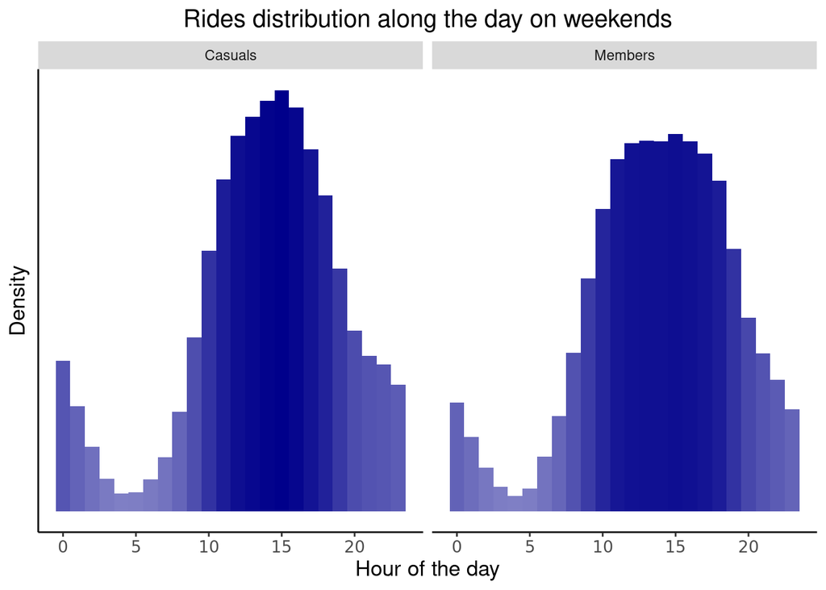

```r
ggplot(data = df_wke, mapping = aes(x = lubridate::hour(started_at), y = ..density.., alpha = ..density..)) +
  geom_histogram(bins = 24, fill = 'darkblue', show.legend = FALSE) +
  facet_wrap(~member_casual, labeller = as_labeller(c('casual' = 'Casuals', 'member' = 'Members'))) + #Labels of facets
  labs(x = 'Hour of the day',
       y = 'Density',
       title = 'Rides distribution along the day on weekends') +
  theme(panel.grid.major = element_blank(),
        panel.grid.minor = element_blank(),
        panel.background = element_rect(fill = "white"),
        axis.line = element_line(color = 'black'),
        axis.text = element_text("black", size = 10),
        axis.text.y = element_blank(),
        axis.ticks.y = element_blank(),
        axis.title = element_text(size = 13),
        plot.title = element_text(hjust = 0.5, size = 15)) +
  scale_alpha(range = c(0.5, 1))
```

It can be seen that the bicycle use is almost the same on weekends but different on weekdays, this is probably due to members using their bikes to commute to work.

### Month

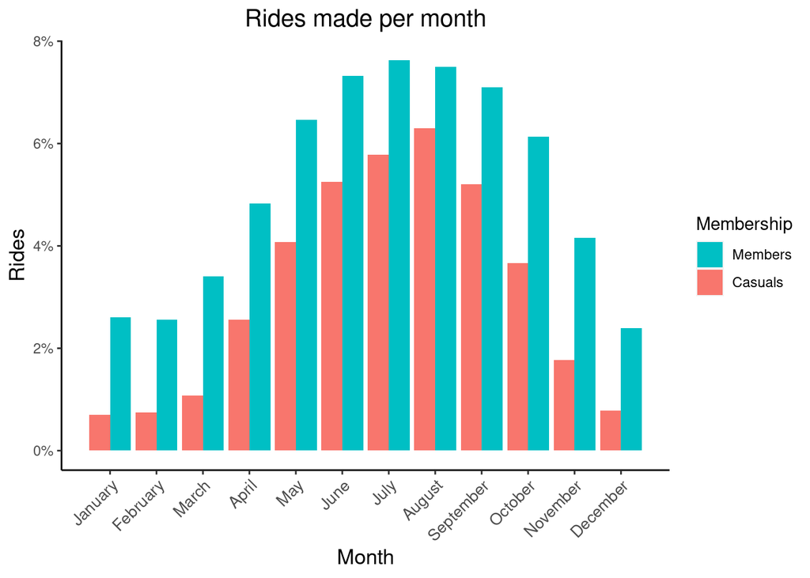

```r
ggplot(data = df, aes(x = month(started_at), y = ..count../sum(..count..), fill = member_casual)) +
  geom_bar(position = 'dodge') +
  scale_fill_discrete("Membership",
                      breaks=c("member","casual"),
                      labels=c("Members", "Casuals")) +
  labs(title = 'Rides made per month') +
  scale_x_continuous('Month', breaks = 1:12, labels = month.name) +
  scale_y_continuous('Rides', labels = scales::percent) +
  theme(panel.grid.major = element_blank(),
        panel.grid.minor = element_blank(),
        panel.background = element_rect(fill = "white"),
        axis.line = element_line(color = 'black'),
        axis.text.x = element_text(size = 10, angle = 45, hjust = 1),
        axis.title = element_text(size = 13),
        plot.title = element_text(hjust = 0.5, size = 15)) +
  scale_alpha(range = c(0.3, 1))
```

From this it is easy to see that the drop of casual rides in winter is much more pronounced than that of members. The reduction in casual users can be almost by a factor of 10, whereas on members the reduction can be by a factor of approximately 3.

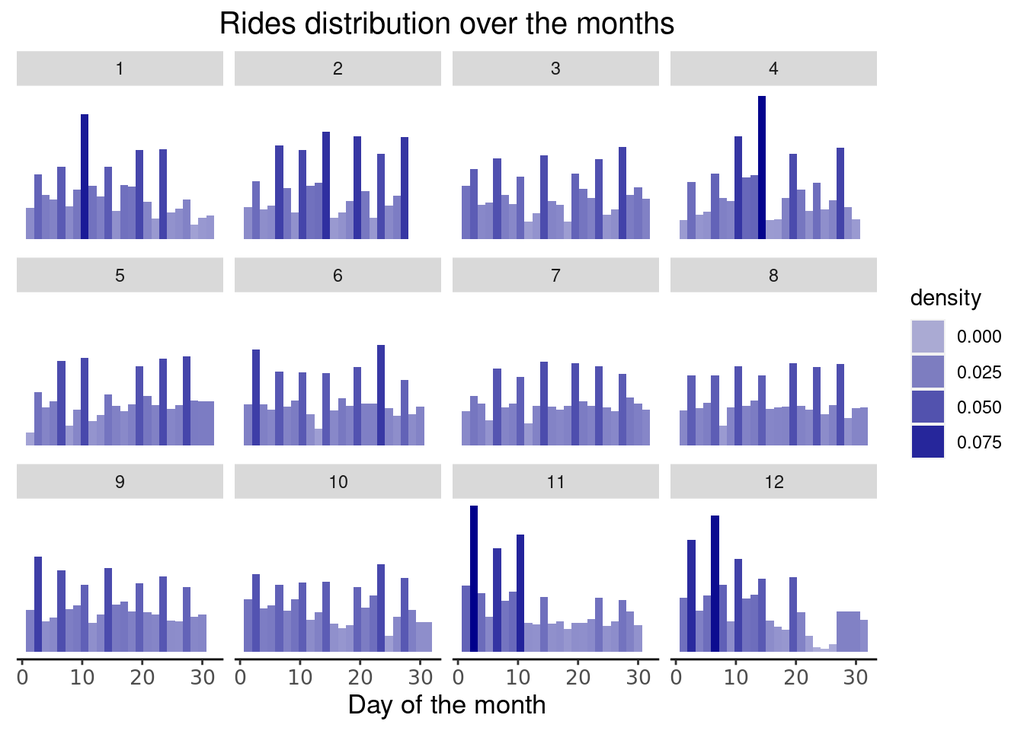

```r
ggplot(data = df, mapping = aes(x = lubridate::day(started_at), y = ..density.., alpha = ..density..)) +
  geom_histogram(bins = 24, fill = 'darkblue') +
  facet_wrap(~month(started_at)) + #Labels of facets
  labs(x = 'Day of the month',
       title = 'Rides distribution over the months') +
  theme(panel.grid.major = element_blank(),
        panel.grid.minor = element_blank(),
        panel.background = element_rect(fill = "white"),
        axis.line.x = element_line(color = 'black'),
        axis.text.x = element_text("black", size = 10),
        axis.text.y = element_blank(),
        axis.title.y = element_blank(),
        axis.line.y = element_blank(),
        axis.ticks.y = element_blank(),
        axis.title = element_text(size = 13),
        plot.title = element_text(hjust = 0.5, size = 15)) +
  scale_alpha(range = c(0.3, 1))
```

The peaks in these month distributions caught my attention, however I haven’t found a strong argument that explains them. Basically I would expect 4 peaks per month due to a weekly cycle, on the other hand , I would also expect an increase in bicycle usage on holidays, but they’re not that common. Other explanations may be:

- Paydays
- Government benefit
- Holidays that I don’t know
- Weather
- Other cyclical events.
- Error making the plot

### Bike type

```r
rideable_type_df <- df %>%
  select(ride_id, rideable_type, member_casual) %>%
  group_by(rideable_type, member_casual) %>%
  summarise(total = sum(!is.na(member_casual)))
```

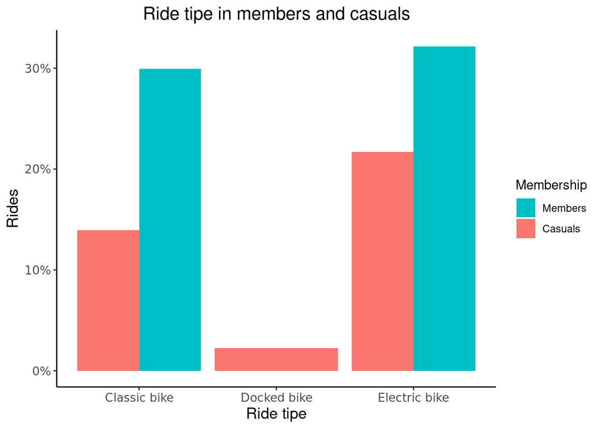

```r
ggplot(data = rideable_type_df, mapping = aes(x = rideable_type, y = total/sum(total), fill = member_casual)) +
  geom_bar(position='dodge', stat='identity') +
  labs(x = 'Ride tipe',
    y = 'Rides',
    title = 'Ride tipe in members and casuals') +
  scale_fill_discrete("Membership",
                      breaks=c("member","casual"),
                      labels=c("Members", "Casuals")) +
  scale_y_continuous(labels = scales::percent) +
  scale_x_discrete(labels = as_labeller(c('classic_bike' = 'Classic bike', 'docked_bike' = 'Docked bike', 'electric_bike' = 'Electric bike'))) +
    theme(panel.grid.major = element_blank(),
        panel.grid.minor = element_blank(),
        panel.background = element_rect(fill = "white"),
        axis.line = element_line(color = 'black'),
        axis.text = element_text("black", size = 10),
        axis.title = element_text(size = 13),
        plot.title = element_text(hjust = 0.5, size = 15))
```

It can be noticed that only casuals have used docked bikes, however, I have looked up the types of bicicles Divvy has available and there are only two types, electric and classic, therefore this may be an error in the data.

### Top casual stations

Now I’m going to use the information to evaluate which are the stations where casual users start their trips the most. For that purpose, I’ll group the data by stations, counting the members and casuals for each. Then, I’ll make a list of the stations with higher casual/member ratio (for those stations with more than 1000 users, because focusing on stations with less than approximately 3 users per day can be a waste of resources).

```r
top_casual_stations <- df %>%
  select(start_station_name, member_casual) %>%
  group_by(start_station_name) %>%
  summarise(members = sum(member_casual == 'member'),
            casuals = sum(member_casual == 'casual')) %>%
  filter((members+casuals) >= 1000) %>%
  mutate(casual_member_ratio = casuals/members) %>%
  arrange(desc(casuals/members))


head(top_casual_stations)
```

```
## # A tibble: 6 × 4
##   start_station_name                members casuals casual_member_ratio
##   <chr>                               <int>   <int>               <dbl>
## 1 Buckingham Fountain                  1068    4287                4.01
## 2 Field Museum                         1986    7943                4.00
## 3 Shedd Aquarium                       4750   18257                3.84
## 4 DuSable Lake Shore Dr & Monroe St    9141   29488                3.23
## 5 Streeter Dr & Grand Ave             16732   48800                2.92
## 6 Dusable Harbor                       5188   13598                2.62
```

Here it can be noticed that stations with higher casual-to-member ratio have not necessarily higher casual rides

It is also important to focus on the absolute value of casual members:

```r
head(arrange(top_casual_stations, desc(casuals)))
```

```
## # A tibble: 6 × 4
##   start_station_name                   members casuals casual_member_ratio
##   <chr>                                  <int>   <int>               <dbl>
## 1 ""                                    501693  323491               0.645
## 2 "Streeter Dr & Grand Ave"              16732   48800               2.92
## 3 "DuSable Lake Shore Dr & Monroe St"     9141   29488               3.23
## 4 "Michigan Ave & Oak St"                14391   22652               1.57
## 5 "Millennium Park"                       9537   21851               2.29
## 6 "DuSable Lake Shore Dr & North Blvd"   15170   20474               1.35
```

### Location

I would also like to make a visualization that shows a map and the places were members and casual users started their trip.

Before making fancy any stuff, lets plot the histograms of the rides and the latitude just to see if they-re somehow different

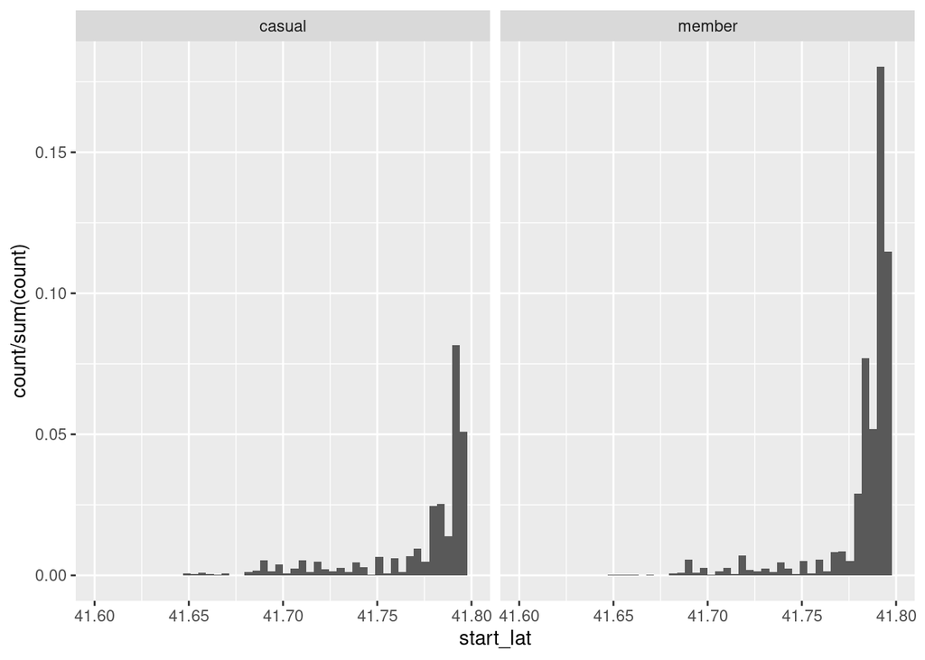

```r
ggplot(data = df, mapping = aes(x = start_lat, y = ..count../sum(..count..))) +
  geom_histogram(bins = 50) +
  xlim(41.6, 41.8) +
  facet_wrap(~member_casual)
```

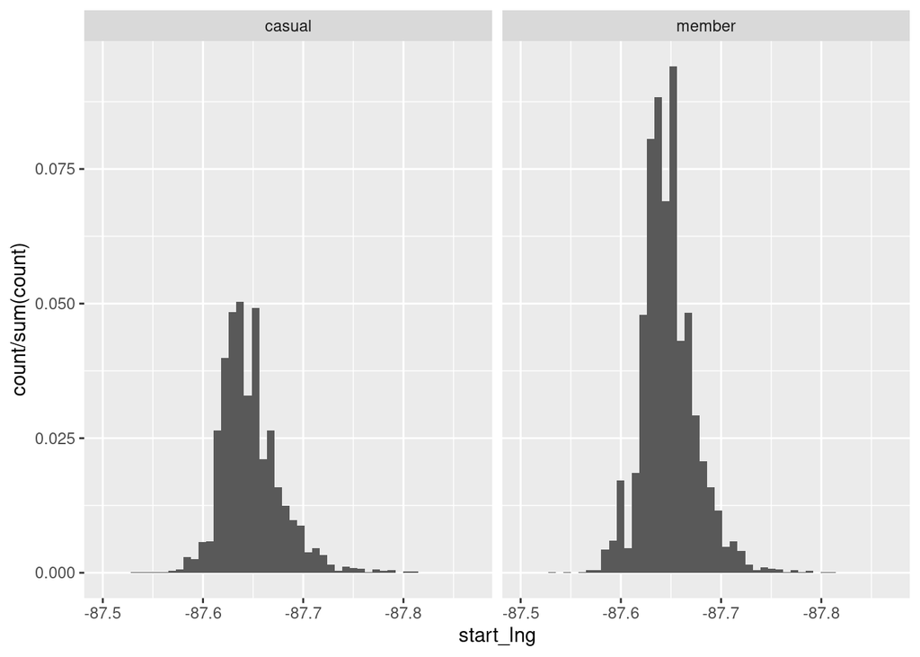

```r
ggplot(data = df, mapping = aes(x = start_lng, y = ..count../sum(..count..))) +
  geom_histogram(bins = 50) +
  xlim(-87.5, -87.87) +
  facet_wrap(~member_casual)
```

With those histograms one can see that casuals and members are not equally distributed even if the longitude distibution is very similar. Since plotting a spatial heatmap of the trips made by casuals and members is much easier in Tableau, I’m going to export only the columns of interest (the entire df is more than 1 GB)

```r
df_for_tableau <- df %>%
  select(ride_id,
         started_at,
         ended_at,
         start_lng,
         start_lat,
         member_casual)

write_csv(df_for_tableau, 'cyclist_data_tableau.csv')
```